# BS-Support Results

Jade Yonehiro

May 2020

```r
# Load Aggregated Data File
## PC Pathway
dfAgg = read.delim("C:/Users/Jade/Dropbox/0_Studies/1_InhibCtrl2019/0_Analyses/2020_MotionTracking/202005_AggregateData_BsSupport.csv",sep=",", header = TRUE)
## Mac Pathway
#dfAgg = read.delim("~/Dropbox/0_Studies/1_InhibCtrl2019/0_Analyses//2020_MotionTracking/202005_AggregateData_BsSupport.csv",sep=",", header = TRUE)

# Set theme for plotting
mytheme <-theme(panel.grid.major = element_blank(), panel.grid.minor = element_blank(),
          panel.background = element_blank(), axis.line = element_line(colour = "black"))
```

# Accuracy

```r
# set up data frame for analysis
dfAcc<-dfAgg%>%
  group_by(part_id, cueDum, cueContrast, tType, ageRound)%>%
  summarise(MuACC = mean(acc, rm.na=T))%>%
  ungroup()
```

## Accuracy across All trial types

Question

Overall, did accuracy differ between the two conditions (Cue v. No-Cue) and across age (3-7)?

$\bar{ACC_i}= \beta_0+\beta_1Age_i+\beta_2Condition_i+\beta_3TrialType_i+...\beta_7Age*Condition_i*TrialType+\epsilon_i$

Results

```r
AccCont<-lm(MuACC ~ ageRound + cueContrast + tType + ageRound*tType*cueContrast, dfAcc)
mcSummary(AccCont)
```

```
## lm(formula = MuACC ~ ageRound + cueContrast + tType + ageRound *
##     tType * cueContrast, data = dfAcc)
##
## Omnibus ANOVA
##               SS  df    MS EtaSq     F p
## Model      1.028   7 0.147 0.131 6.358 0
## Error      6.838 296 0.023
## Corr Total 7.866 303 0.026
##
##   RMSE AdjEtaSq
##  0.152     0.11
##
## Coefficients
##                               Est StErr      t SSR(3) EtaSq   tol CI_2.5
## (Intercept)                 0.758 0.037 20.701  9.900 0.591    NA  0.686
## ageRound                    0.034 0.007  4.834  0.540 0.073 0.979  0.020
## cueContrast                -0.002 0.073 -0.033  0.000 0.000 0.057 -0.147
## tType                       0.203 0.073  2.769  0.177 0.025 0.057  0.059
## ageRound:tType             -0.027 0.014 -1.898  0.083 0.012 0.057 -0.054
## ageRound:cueContrast        0.002 0.014  0.125  0.000 0.000 0.058 -0.026
## cueContrast:tType           0.113 0.146  0.773  0.014 0.002 0.057 -0.175
## ageRound:cueContrast:tType -0.024 0.028 -0.866  0.017 0.003 0.057 -0.080
##                            CI_97.5     p
## (Intercept)                  0.830 0.000
## ageRound                     0.048 0.000
## cueContrast                  0.142 0.973
## tType                        0.347 0.006
## ageRound:tType               0.001 0.059
## ageRound:cueContrast         0.029 0.901
## cueContrast:tType            0.401 0.440
## ageRound:cueContrast:tType   0.031 0.387
```

## Accuracy on GO trials.

Question

Did accuracy differ between the two conditions (Cue v.No-Cue) and across ages (3-7)in the GO trials?

$\bar{GOACC_i}= \beta_0+\beta_1Age_i+\beta_2Condition_i+\beta_3Age*Condition_i+\epsilon_i$

Results

```r
AccContGO<-lm(MuACC ~ ageRound + cueDum + ageRound*cueDum, dfAcc, subset = tType == 0.5)
mcSummary(AccContGO)
```

```
## lm(formula = MuACC ~ ageRound + cueDum + ageRound * cueDum, data = dfAcc,
##     subset = tType == 0.5)
##
## Omnibus ANOVA
##               SS  df    MS EtaSq     F p
## Model      0.102   3 0.034  0.15 8.719 0
## Error      0.578 148 0.004
## Corr Total 0.680 151 0.005
##
##   RMSE AdjEtaSq
##  0.062    0.133
##
## Coefficients
##                    Est StErr      t SSR(3) EtaSq   tol CI_2.5 CI_97.5     p
## (Intercept)      0.832 0.032 25.747  2.587 0.817    NA  0.768   0.896 0.000
## ageRound         0.026 0.006  4.249  0.070 0.109 0.442  0.014   0.038 0.000
## cueDum           0.054 0.043  1.272  0.006 0.011 0.057 -0.030   0.138 0.205
## ageRound:cueDum -0.010 0.008 -1.275  0.006 0.011 0.056 -0.027   0.006 0.204
```

## Accuracy on NO-GO trials

Question.

Did accuracy differ between the two conditions (Cue v. No-Cue) and across ages (3-7) in the **NO-GO trials**?

$\bar{NOGOACC_i}= \beta_0+\beta_1Age_i+\beta_2Condition_i+\beta_3Age*Condition_i+\epsilon_i$

Results

- **Age:** Age (3-7) was a significant predictor of accuracy on No-Go trials (p=.045). Children’s accuracy increased with age.
- **Condition:** *Not Significant*
- **Interaction:** *Not Significant*

```r
AccContNOGO<-lm(MuACC ~ ageRound + cueDum + ageRound*cueDum, dfAcc, subset = tType == -0.5)
mcSummary(AccContNOGO)
```

```
## lm(formula = MuACC ~ ageRound + cueDum + ageRound * cueDum, data = dfAcc,
##     subset = tType == -0.5)
##
## Omnibus ANOVA
##               SS  df    MS EtaSq     F     p
## Model      0.558   3 0.186 0.082 4.397 0.005
## Error      6.260 148 0.042
## Corr Total 6.818 151 0.045
##
##   RMSE AdjEtaSq
##  0.206    0.063
##
## Coefficients
##                    Est StErr      t SSR(3) EtaSq   tol CI_2.5 CI_97.5     p
## (Intercept)      0.686 0.106  6.447  1.758 0.219    NA  0.476   0.896 0.000
## ageRound         0.040 0.020  2.015  0.172 0.027 0.442  0.001   0.080 0.046
## cueDum          -0.059 0.140 -0.421  0.008 0.001 0.057 -0.336   0.218 0.674
## ageRound:cueDum  0.014 0.027  0.518  0.011 0.002 0.056 -0.039   0.067 0.605
```

## Visualizations & Summary

Accuracy Results Summary

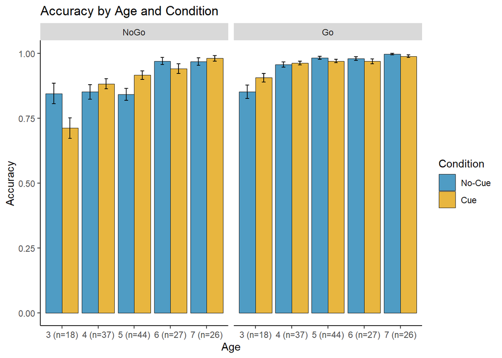

```r
dfAccplot<-dfAgg%>%
  ungroup()%>%
  mutate(cueDum=as.factor(cueDum),
         tType = factor(tType, levels=c(-.5,.5),labels=c("NoGo","Go")))%>%
  filter(!is.na(ageRound), !is.na(acc), !is.na(tType))%>%
  group_by(ageRound, tType, cueDum)%>%
  summarise(mean = mean(acc, na.rm=TRUE),
            se = sd(acc)/sqrt(length(acc)))%>%
  ungroup()%>%
  mutate(age = ifelse(ageRound==3, '3 (n=18)',
                   ifelse(ageRound==4, '4 (n=37)',
                       ifelse(ageRound==5, '5 (n=44)',
                           ifelse(ageRound==6, '6 (n=27)',
                                ifelse(ageRound==7, '7 (n=26)', NA))))))
PlotACC <- ggplot(dfAccplot, aes(age, mean, fill=cueDum)) +
    geom_bar(stat = "identity",position=position_dodge(),color="black", size=.3) +
    scale_fill_manual(name="Condition",labels = c("No-Cue", "Cue"),values=c("#4F9CC4", "#e8b63f")) +
    ggtitle("Accuracy by Age and Condition") +
    geom_errorbar(aes(ymin=mean-se, ymax=mean + se), width=.2,
                  position=position_dodge(.9)) +
    mytheme+
    ylab("Accuracy")+
    xlab("Age")+
    facet_wrap(~tType)
PlotACC
```

### Summary Stats

Age x Cue Condition x Trial Type

| Age | cueDum | Trial Type | Mean Accuracy | Accuracy se |
| --- | --- | --- | --- | --- |
| 3 | No Cue | NoGo | 0.8452381 | 0.0396993 |
| 3 | No Cue | Go | 0.8520408 | 0.0254263 |
| 3 | Cue | NoGo | 0.7121212 | 0.0395591 |
| 3 | Cue | Go | 0.9058442 | 0.0166679 |
| 4 | No Cue | NoGo | 0.8511905 | 0.0275404 |
| 4 | No Cue | Go | 0.9566327 | 0.0103007 |
| 4 | Cue | NoGo | 0.8823529 | 0.0195716 |
| 4 | Cue | Go | 0.9625000 | 0.0075156 |
| 5 | No Cue | NoGo | 0.8416667 | 0.0236133 |
| 5 | No Cue | Go | 0.9821429 | 0.0056013 |
| 5 | Cue | NoGo | 0.9157895 | 0.0164787 |
| 5 | Cue | Go | 0.9700150 | 0.0066085 |
| 6 | No Cue | NoGo | 0.9702381 | 0.0131496 |
| 6 | No Cue | Go | 0.9795918 | 0.0071505 |
| 6 | Cue | NoGo | 0.9411765 | 0.0190849 |
| 6 | Cue | Go | 0.9693593 | 0.0091086 |
| 7 | No Cue | NoGo | 0.9679487 | 0.0141476 |
| 7 | No Cue | Go | 0.9972222 | 0.0027778 |
| 7 | Cue | NoGo | 0.9807692 | 0.0110310 |
| 7 | Cue | Go | 0.9888889 | 0.0055323 |

# Response Time

```r
dfRT<-dfAgg%>%
  group_by(part_id, ageRound, cueDum, tType, acc)%>%
  summarise(MuRT = mean(reachRT))%>%
  ungroup()
```

**NOTES**  
- We can only look at response times for accurate Go trials and inaccurate No-Go trials  
- Inaccurate Go trials and Accurate No-Go trials time out, so there is no time stamp for when they opened the box. Since reach response times are calculated as $(Box Open Time)-(Stim Presentation Time)$ these trials have a 0 value (or could be replaced with MAX reach time possible)

## Response times on accurate GO trials

Question

Did response times differ between the two conditions (Cue v. No-Cue) and across ages (3-7) in the GO trials?

$\bar{GORT_i}= \beta_0+\beta_1Age_i+\beta_2Condition_i+\beta_3Age*Condition_i+\epsilon_i$

Results

```r
RTContGO<-lm(MuRT ~ ageRound + cueDum + ageRound*cueDum, dfRT, subset = tType == 0.5 & acc==1)
mcSummary(RTContGO)
```

```
## lm(formula = MuRT ~ ageRound + cueDum + ageRound * cueDum, data = dfRT,
##     subset = tType == 0.5 & acc == 1)
##
## Omnibus ANOVA
##                  SS  df         MS EtaSq      F p
## Model      11884462   3 3961487.23 0.448 40.069 0
## Error      14632201 148   98866.22
## Corr Total 26516662 151  175607.04
##
##    RMSE AdjEtaSq
##  314.43    0.437
##
## Coefficients
##                      Est   StErr      t     SSR(3) EtaSq   tol   CI_2.5
## (Intercept)     1926.801 162.709 11.842 13864344.0 0.487    NA 1605.269
## ageRound        -134.662  30.557 -4.407  1920056.7 0.116 0.442 -195.047
## cueDum           589.937 214.252  2.753   749564.8 0.049 0.057  166.549
## ageRound:cueDum  -48.490  41.051 -1.181   137944.7 0.009 0.056 -129.611
##                  CI_97.5     p
## (Intercept)     2248.334 0.000
## ageRound         -74.277 0.000
## cueDum          1013.325 0.007
## ageRound:cueDum   32.632 0.239
```

## Response times on inaccurate NO-GO trials

Question

$\bar{NOGORT_i}= \beta_0+\beta_1Age_i+\beta_2Condition_i+\beta_3Age*Condition_i+\epsilon_i$

Results

```r
RTContNOGO<-lm(MuRT ~ ageRound + cueDum + ageRound*cueDum, dfRT, subset = tType == -0.5 & acc==0)
mcSummary(RTContNOGO)
```

```
## lm(formula = MuRT ~ ageRound + cueDum + ageRound * cueDum, data = dfRT,
##     subset = tType == -0.5 & acc == 0)
##
## Omnibus ANOVA
##                  SS df        MS EtaSq     F p
## Model       5515089  3 1838363.1 0.296 8.258 0
## Error      13134679 59  222621.7
## Corr Total 18649768 62  300802.7
##
##     RMSE AdjEtaSq
##  471.828     0.26
##
## Coefficients
##                      Est   StErr      t    SSR(3) EtaSq   tol   CI_2.5  CI_97.5
## (Intercept)     1976.526 370.112  5.340 6349020.0 0.326    NA 1235.934 2717.118
## ageRound        -158.102  74.503 -2.122 1002528.5 0.071 0.465 -307.182   -9.022
## cueDum           643.528 494.712  1.301  376702.2 0.028 0.058 -346.388 1633.444
## ageRound:cueDum  -70.485 102.598 -0.687  105073.1 0.008 0.058 -275.783  134.812
##                     p
## (Intercept)     0.000
## ageRound        0.038
## cueDum          0.198
## ageRound:cueDum 0.495
```

## Visualizations & Summary

Response Time Results Summary

- Across these analyses, age was a consistent predictor of children’s response times on the box-search task (Accuracte Go trials and inaccurate No-go trials only). We found that response times decreased with age in both Go and No-go trials. We found that condition was a significant predictor of response times on accurate Go trials. Children’s Go trial response times were slower in the Cue condition than in the No-cue conditin.w

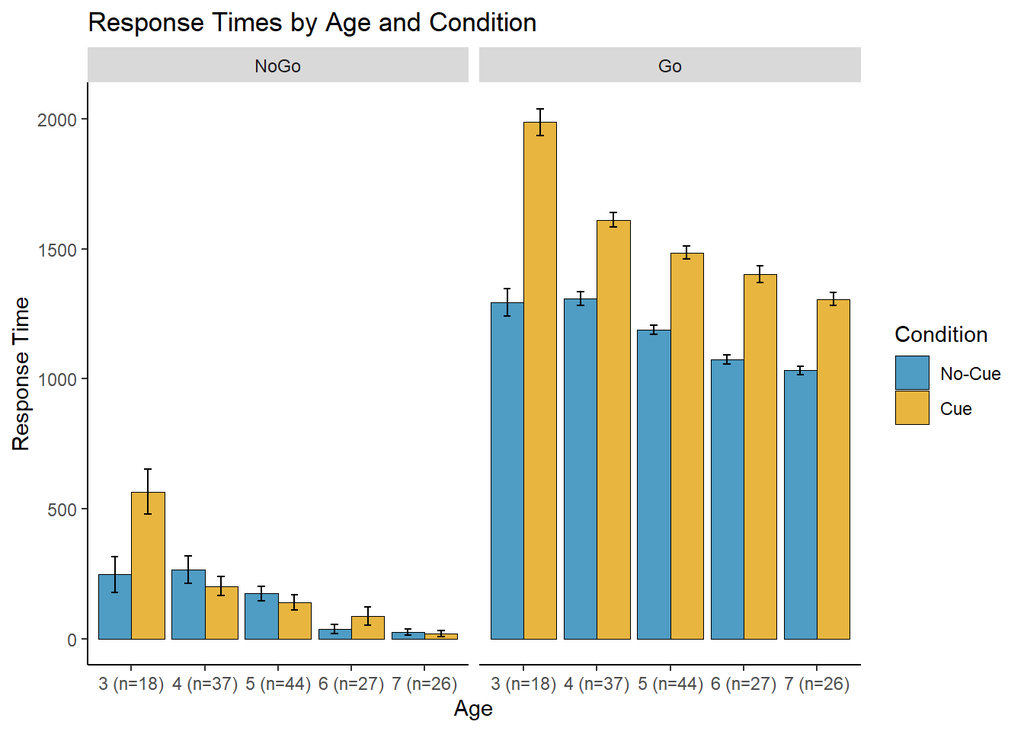

```r
dfplot<-dfAgg%>%
  mutate(cueDum = as.factor(cueDum),
         tType = factor(tType, levels=c(-.5,.5),labels=c("NoGo","Go"))) %>%
  filter(!is.na(ageRound), !is.na(reachRT), !is.na(tType)) %>%
  group_by(ageRound, tType, cueDum) %>%
  summarise(mean = mean(reachRT, na.rm=TRUE),
            se = sd(reachRT)/sqrt(length(reachRT)))%>%
  ungroup()%>%
  mutate(age = ifelse(ageRound==3, '3 (n=18)',
                    ifelse(ageRound==4, '4 (n=37)',
                        ifelse(ageRound==5, '5 (n=44)',
                            ifelse(ageRound==6, '6 (n=27)',
                                 ifelse(ageRound==7, '7 (n=26)', NA))))))
PlotRT<-ggplot(dfplot,aes(age, mean, fill=cueDum)) +
    geom_bar(stat = "identity",position=position_dodge(),color="black", size=.3) +
    scale_fill_manual(name="Condition",labels = c("No-Cue", "Cue"),values=c("#4F9CC4", "#e8b63f")) +
    geom_errorbar(aes(ymin=mean-se, ymax=mean + se), width=.2,
                  position=position_dodge(.9)) +
    ggtitle("Response Times by Age and Condition") +
    mytheme+
    ylab("Response Time")+
    xlab("Age")+
    facet_wrap(~tType)

 PlotRT
```

5yos only Response Times available in older script versions